# DADA2 through Phyloseq

In this script, raw fastq files will be cleaned, aligned to reference genome and corrected for various effects. The initial data processing and clean up was based on the DADA2 pipeline found [here](https://benjjneb.github.io/dada2/tutorial.html). This dataset first needs to be filtered to only include the files of the samples with the corresponding diet data. Additionally, the sequences were analyzed in 5 separate batches and this effects will need to be accounted for. The workflow is listed below

# Workflow

**Step 1:** Run DADA2 for all batches

**Step 2:** Convert to Phyloseq & Contaminant Removal

**Step 3:** Batch Correction and merge with COMBATseq

##### Load Library

Use devtools to install packages if problematic

```r
library(captioner)
library(here)
library(tidyverse)
library(devtools)
library(dada2)
library(sva)
library(phyloseq)
library(ape)
library(decontam)
```

## DADA2 - raw 16SRNA analysis

### File Import

#### Mapfile

Creation of the sample data: The Mapfile contains all information for each fastq file including the redcapid, sample type, batch number etc. This is what will be used to filter the fastq files to those of interest and later to create the sample data for phyloseq

```r
#Step 1: Import mapfile: contains IDs and description of the sample
#######################################################################
Mapfile <- read.csv(here::here("Data", "Microbiome_Data", "mapFile_PMH_05272021.csv"))


#Step 2: Filter Mapfile to only have redcapids from our diet data
#######################################################################
##Import list of redcapids (computed from the Diet analysis script)
redcapids <- read.csv(here::here("Data", "Microbiome_Data", "Diet_redcapids.csv"))
redcapids2 <- data.frame(redcapids[,-1])

#Filter Mapfile by Diet redcapids
filter1 <- redcapids2$redcapid
filter2 <- c(0,1)
Mapfile2 <- Mapfile %>%
  filter(ParticipantID %in% filter1) %>%
  filter(Visit %in% filter2)

#Step 3: Filter separate mapfile for the controls
#######################################################################

Mapfile3 <- filter(Mapfile, ParticipantID == "NONE")

#Remove Positive controls
Mapfile3 <- filter(Mapfile3, !(SampleName %in% c("Zymo_mock_A", "Zymo_mock_B",
                                                 "Zymo_mock_C", "Zymo_mock_D",
                                                  "Zymo_mock_E", "Zymo_mock_F", "Zymo_mock_G", "Zymo_mock_H",
                                                 "Zymo_Mock_G4", "Zymo_Mock_G5", "Zymo_Mock_G6", "Zymo_Mock_G7",
                                                 "Zymo_Mock_G8", "Zymo_Mock_G9", "Zymo_Mock_G10", "Zymo_Mock_G11",
                                                 "Zymo_Mock_G12")))


#Step 4: Merge the two filtered dataframes
#######################################################################
Mapfile4 <- merge(Mapfile2, Mapfile3, all = TRUE)

#Step 5: Add in what their FFQ type was
#######################################################################
FFQ_type <- read.csv(here("Data", "Blood Data","Date_FFQ_ID_HGB.csv"))
FFQ_type <- FFQ_type %>% rename("ParticipantID" = "redcapid")
Mapfile4 <- merge(Mapfile4, FFQ_type, by = "ParticipantID", all=TRUE)
Mapfile <- Mapfile4[,-c(42,44:46)]

#Add the controls back in
Mapfile <- Mapfile <- merge(Mapfile, Mapfile3, all = TRUE)
Mapfile <- Mapfile[-c(168,169),]

#List of names to use to hard call the files we want
mapfile_comp <- Mapfile$SampleID
mapfileF_comp <- paste(mapfile_comp, "R1.fastq", sep = "_")
```

#### Fastq file import and Selection

Files used have already been split by sample into the forward and reverse files by batch. Since Batch4 is missing its reverse sequences, we excluded all reverse sequences from this analysis. Runs = batches. Batch 4 was excluded due to poor sequencing

```r
#Step 1: Import Files &filter by mapfile names ###########################################
#Batch1
fnFs1 <- sort(list.files(here("Data", "Microbiome_Data", "fastq", "Run1SplitbySample", "R1"),
                         pattern = paste0(mapfileF_comp, collapse="|"), full.names = TRUE))
#Batch2
fnFs2 <- sort(list.files(here("Data", "Microbiome_Data", "fastq", "Run2SplitBySample", "R1"),
                         pattern = paste0(mapfileF_comp, collapse="|"), full.names = TRUE))

#Batch3
fnFs3 <- sort(list.files(here("Data", "Microbiome_Data", "fastq", "Run3SplitBySample", "R1"),
                         pattern = paste0(mapfileF_comp, collapse="|"), full.names = TRUE))

#Batch5
fnFs5 <- sort(list.files(here("Data", "Microbiome_Data", "fastq", "Run5SplitbySample", "R1"),
                         pattern = paste0(mapfileF_comp, collapse="|"), full.names = TRUE))

#Step 2: Prep the group stringsplit for later use ######################################
sample.names1 <- sapply(strsplit(basename(fnFs1), "_"), `[`, 1)
sample.names2 <- sapply(strsplit(basename(fnFs2), "_"), `[`, 1)
sample.names3 <- sapply(strsplit(basename(fnFs3), "_"), `[`, 1)
sample.names5 <- sapply(strsplit(basename(fnFs5), "_"), `[`, 1)
```

### Quality Plot Profiles

**Green line:** Mean quality score  
**Orange line:** quartile of the quality score  
**Red line:** scaled proportion of read going to the last position

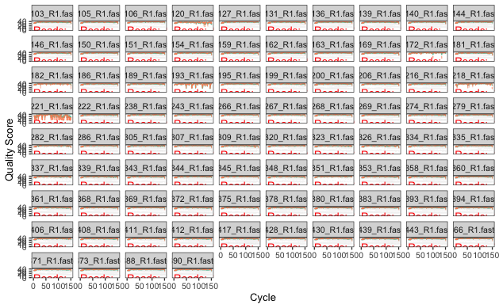

```r
#Batch1
#######################################################################
plotQualityProfile(fnFs1)
```

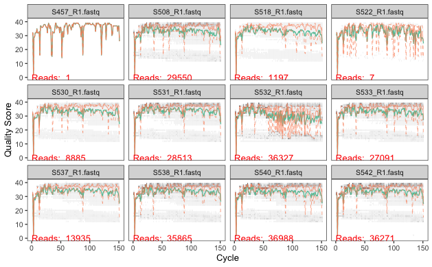

```r
#Batch2
#######################################################################
plotQualityProfile(fnFs2)
```

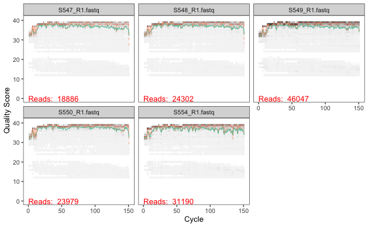

```r
#Batch3
#######################################################################
plotQualityProfile(fnFs3)
```

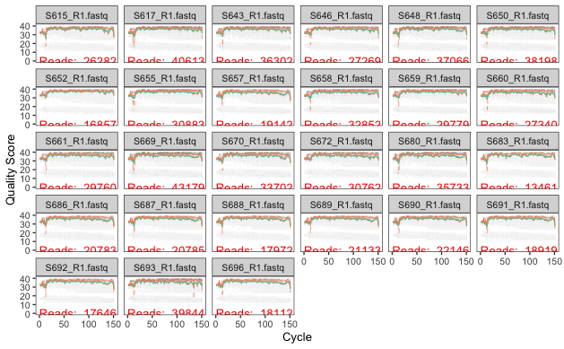

```r
#Batch5
#######################################################################
plotQualityProfile(fnFs5)
```

### Filter and Trim Sequences

Trimmed & filtered sequences will be contained in one single folder in the Microbiome_Output folder.

```r
# Place filtered files in filtered/ subdirectory

#Batch1
#######################################################################
filtFs1 <- file.path(here("Output", "Microbiome_Output"), "Run1filtered", paste0(sample.names1, "_F_filt.fastq.gz"))
names(filtFs1) <- sample.names1

out1 <- filterAndTrim(fnFs1, filtFs1, truncLen=150, trimLeft = 5,
              maxN=0, maxEE=2, truncQ=2, rm.phix=TRUE,
              compress=TRUE, multithread=TRUE)

#Batch2
#######################################################################
filtFs2 <- file.path(here("Output", "Microbiome_Output"), "Run2filtered", paste0(sample.names2, "_F_filt.fastq.gz"))
names(filtFs2) <- sample.names2

out2 <- filterAndTrim(fnFs2, filtFs2, truncLen=150, trimLeft = 5,
              maxN=0, maxEE=2, truncQ=2, rm.phix=TRUE,
              compress=TRUE, multithread=TRUE)

#Batch3
#######################################################################
filtFs3 <- file.path(here("Output", "Microbiome_Output"), "Run3filtered", paste0(sample.names3, "_F_filt.fastq.gz"))
names(filtFs3) <- sample.names3

out3 <- filterAndTrim(fnFs3, filtFs3, truncLen=150, trimLeft = 5,
              maxN=0, maxEE=2, truncQ=2, rm.phix=TRUE,
              compress=TRUE, multithread=TRUE)

#Batch5
#######################################################################
filtFs5 <- file.path(here("Output", "Microbiome_Output"), "Run5filtered", paste0(sample.names5, "_F_filt.fastq.gz"))
names(filtFs5) <- sample.names5

out5 <- filterAndTrim(fnFs5, filtFs5, truncLen=150, trimLeft = 5,
              maxN=0, maxEE=2, truncQ=2, rm.phix=TRUE,
              compress=TRUE, multithread=TRUE)

# Check how each batch was filtered
#######################################################################
head(out1)
```

```
              reads.in reads.out
S103_R1.fastq    17602     17448
S105_R1.fastq    14248     14136
S106_R1.fastq      949       949
S120_R1.fastq        9         9
S127_R1.fastq    26238     26067
S131_R1.fastq    15371     15224
```

```r
head(out2)
```

```
              reads.in reads.out
S457_R1.fastq        1         1
S508_R1.fastq    29550     28520
S518_R1.fastq     1197      1145
S522_R1.fastq        7         7
S530_R1.fastq     8885      8637
S531_R1.fastq    28513     28039
```

```r
head(out3)
```

```
              reads.in reads.out
S547_R1.fastq    18886     18598
S548_R1.fastq    24302     24024
S549_R1.fastq    46047     45157
S550_R1.fastq    23979     23704
S554_R1.fastq    31190     30841
```

```r
head(out5)
```

```
              reads.in reads.out
S615_R1.fastq    26282     26063
S617_R1.fastq    40613     40268
S643_R1.fastq    36302     35992
S646_R1.fastq    27269     26964
S648_R1.fastq    37066     36715
S650_R1.fastq    38198     37829
```

### Learn Error Rates

```r
#Batch1
err1 <- learnErrors(filtFs1, multithread = TRUE)
```

```
102094645 total bases in 704101 reads from 62 samples will be used for learning the error rates.
```

```r
#Batch2
err2 <- learnErrors(filtFs2, multithread = TRUE)
```

```
35851105 total bases in 247249 reads from 12 samples will be used for learning the error rates.
```

```r
#Batch3
err3 <- learnErrors(filtFs3, multithread = TRUE)
```

```
20636980 total bases in 142324 reads from 5 samples will be used for learning the error rates.
```

```r
#Batch5
err5 <- learnErrors(filtFs5, multithread = TRUE)
```

```
104313725 total bases in 719405 reads from 26 samples will be used for learning the error rates.
```

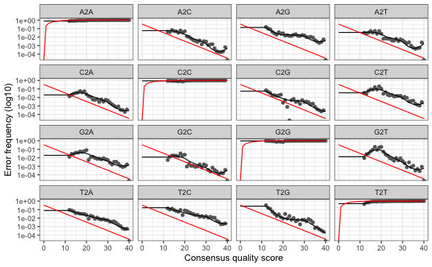

```r
#Visualize the Error rates
plotErrors(err1, nominalQ = TRUE)
```

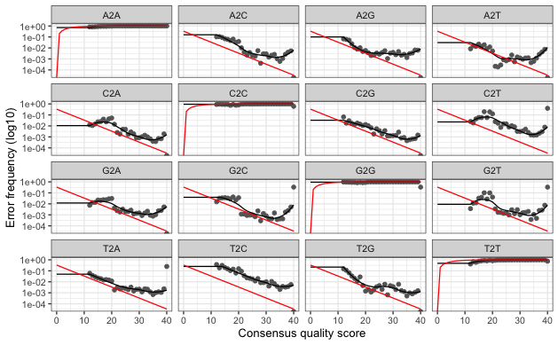

```r
plotErrors(err2, nominalQ = TRUE)
```

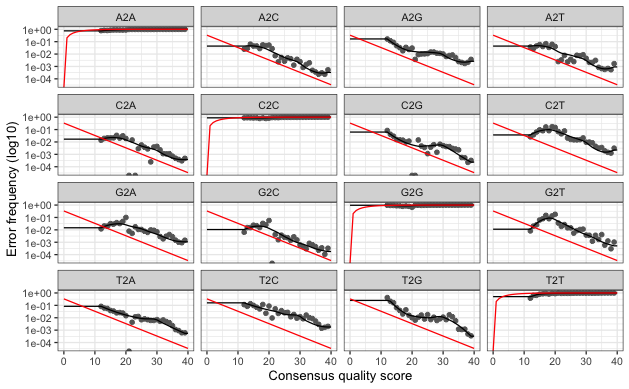

```r
plotErrors(err3, nominalQ = TRUE)
```

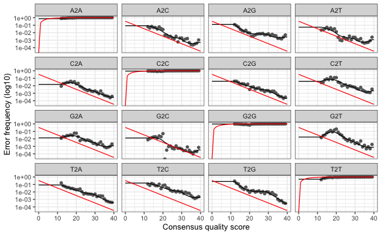

```r
plotErrors(err5, nominalQ = TRUE)
```

### Sample Inference

Unsure about the qualities of these reads

```r
#Batch1
dadaFs1 <- dada(filtFs1, err=err1, multithread = TRUE)
```

```
Sample 1 - 17448 reads in 4637 unique sequences.
Sample 2 - 14136 reads in 3798 unique sequences.
Sample 3 - 949 reads in 382 unique sequences.
Sample 4 - 9 reads in 7 unique sequences.
Sample 5 - 26067 reads in 4482 unique sequences.
Sample 6 - 15224 reads in 3583 unique sequences.
Sample 7 - 29068 reads in 5653 unique sequences.
Sample 8 - 19877 reads in 5033 unique sequences.
Sample 9 - 20068 reads in 4204 unique sequences.
Sample 10 - 24298 reads in 4509 unique sequences.
Sample 11 - 4723 reads in 1552 unique sequences.
Sample 12 - 14292 reads in 2502 unique sequences.
Sample 13 - 15325 reads in 4282 unique sequences.
Sample 14 - 7996 reads in 2319 unique sequences.
Sample 15 - 5907 reads in 1934 unique sequences.
Sample 16 - 9591 reads in 2538 unique sequences.
Sample 17 - 16579 reads in 3329 unique sequences.
Sample 18 - 5762 reads in 1341 unique sequences.
Sample 19 - 3 reads in 1 unique sequences.
Sample 20 - 2655 reads in 679 unique sequences.
Sample 21 - 4 reads in 3 unique sequences.
Sample 22 - 5715 reads in 1672 unique sequences.
Sample 23 - 15598 reads in 3040 unique sequences.
Sample 24 - 1 reads in 1 unique sequences.
Sample 25 - 167 reads in 89 unique sequences.
Sample 26 - 2408 reads in 743 unique sequences.
Sample 27 - 47022 reads in 10467 unique sequences.
Sample 28 - 3566 reads in 855 unique sequences.
Sample 29 - 23979 reads in 5449 unique sequences.
Sample 30 - 3 reads in 1 unique sequences.
Sample 31 - 2 reads in 2 unique sequences.
Sample 32 - 52209 reads in 9391 unique sequences.
Sample 33 - 6081 reads in 1441 unique sequences.
Sample 34 - 17213 reads in 3763 unique sequences.
Sample 35 - 5902 reads in 1599 unique sequences.
Sample 36 - 148 reads in 60 unique sequences.
Sample 37 - 952 reads in 304 unique sequences.
Sample 38 - 17875 reads in 3564 unique sequences.
Sample 39 - 34702 reads in 7670 unique sequences.
Sample 40 - 28051 reads in 5949 unique sequences.
```

[output cut: 29 more lines]

```
Sample 70 - 25385 reads in 5924 unique sequences.
Sample 71 - 38629 reads in 7484 unique sequences.
Sample 72 - 30456 reads in 7473 unique sequences.
Sample 73 - 1074 reads in 421 unique sequences.
Sample 74 - 27678 reads in 7046 unique sequences.
Sample 75 - 43479 reads in 9536 unique sequences.
Sample 76 - 1316 reads in 539 unique sequences.
Sample 77 - 22878 reads in 5187 unique sequences.
Sample 78 - 30933 reads in 7821 unique sequences.
Sample 79 - 24684 reads in 5590 unique sequences.
Sample 80 - 7176 reads in 1001 unique sequences.
Sample 81 - 10031 reads in 2672 unique sequences.
Sample 82 - 33352 reads in 7199 unique sequences.
Sample 83 - 41446 reads in 7778 unique sequences.
Sample 84 - 21929 reads in 5355 unique sequences.
```

```r
#Batch2
dadaFs2 <- dada(filtFs2, err=err2, multithread = TRUE)
```

```
Sample 1 - 1 reads in 1 unique sequences.
Sample 2 - 28520 reads in 11992 unique sequences.
Sample 3 - 1145 reads in 675 unique sequences.
Sample 4 - 7 reads in 6 unique sequences.
Sample 5 - 8637 reads in 4034 unique sequences.
Sample 6 - 28039 reads in 10799 unique sequences.
Sample 7 - 34572 reads in 19654 unique sequences.
Sample 8 - 26566 reads in 10872 unique sequences.
Sample 9 - 13720 reads in 5703 unique sequences.
Sample 10 - 35045 reads in 12785 unique sequences.
Sample 11 - 35565 reads in 15162 unique sequences.
Sample 12 - 35432 reads in 15303 unique sequences.
```

```r
#Batch3
dadaFs3 <- dada(filtFs3, err=err3, multithread = TRUE)
```

```
Sample 1 - 18598 reads in 5201 unique sequences.
Sample 2 - 24024 reads in 6149 unique sequences.
Sample 3 - 45157 reads in 9876 unique sequences.
Sample 4 - 23704 reads in 4897 unique sequences.
Sample 5 - 30841 reads in 6422 unique sequences.
```

```r
#Batch5
dadaFs5 <- dada(filtFs5, err=err5, multithread = TRUE)
```

```
Sample 1 - 26063 reads in 4780 unique sequences.
Sample 2 - 40268 reads in 8761 unique sequences.
Sample 3 - 35992 reads in 8426 unique sequences.
Sample 4 - 26964 reads in 6698 unique sequences.
Sample 5 - 36715 reads in 8675 unique sequences.
Sample 6 - 37829 reads in 9933 unique sequences.
Sample 7 - 16801 reads in 3395 unique sequences.
Sample 8 - 30586 reads in 7263 unique sequences.
Sample 9 - 18846 reads in 4712 unique sequences.
Sample 10 - 32447 reads in 7734 unique sequences.
Sample 11 - 29542 reads in 5996 unique sequences.
Sample 12 - 26994 reads in 6980 unique sequences.
Sample 13 - 29459 reads in 7251 unique sequences.
Sample 14 - 42466 reads in 10671 unique sequences.
Sample 15 - 33159 reads in 7876 unique sequences.
Sample 16 - 30326 reads in 8510 unique sequences.
Sample 17 - 35198 reads in 9208 unique sequences.
Sample 18 - 13327 reads in 3149 unique sequences.
Sample 19 - 20363 reads in 5717 unique sequences.
Sample 20 - 20488 reads in 5107 unique sequences.
Sample 21 - 17733 reads in 4304 unique sequences.
Sample 22 - 20768 reads in 5340 unique sequences.
Sample 23 - 21769 reads in 5515 unique sequences.
Sample 24 - 18643 reads in 4790 unique sequences.
Sample 25 - 17391 reads in 4710 unique sequences.
Sample 26 - 39268 reads in 9778 unique sequences.
Sample 27 - 17852 reads in 4906 unique sequences.
```

```r
#inspect the dadaclass object??????? unsure about quality of these reads
dadaFs1[[1]]
```

```
dada-class: object describing DADA2 denoising results
171 sequence variants were inferred from 4637 input unique sequences.
Key parameters: OMEGA_A = 1e-40, OMEGA_C = 1e-40, BAND_SIZE = 16
```

```r
dadaFs2[[1]]
```

```
dada-class: object describing DADA2 denoising results
1 sequence variants were inferred from 1 input unique sequences.
Key parameters: OMEGA_A = 1e-40, OMEGA_C = 1e-40, BAND_SIZE = 16
```

```r
dadaFs3[[1]]
```

```
dada-class: object describing DADA2 denoising results
185 sequence variants were inferred from 5201 input unique sequences.
Key parameters: OMEGA_A = 1e-40, OMEGA_C = 1e-40, BAND_SIZE = 16
```

```r
dadaFs5[[1]]
```

```
dada-class: object describing DADA2 denoising results
99 sequence variants were inferred from 4780 input unique sequences.
Key parameters: OMEGA_A = 1e-40, OMEGA_C = 1e-40, BAND_SIZE = 16
```

### Construct Sequence Table

```r
#Make sequence table for each batch
seqtabF1 <- makeSequenceTable(dadaFs1)
seqtabF2 <- makeSequenceTable(dadaFs2)
seqtabF3 <- makeSequenceTable(dadaFs3)
seqtabF5 <- makeSequenceTable(dadaFs5)
```

### Remove Chimeras

```r
#Batch1
seqtab1.nochim <- removeBimeraDenovo(seqtabF1, method="consensus", multithread = TRUE, verbose= TRUE)
```

```
Identified 309 bimeras out of 2858 input sequences.
```

```r
sum(seqtab1.nochim)/sum(seqtabF1)
```

```
[1] 0.9946455
```

```r
#Batch2
seqtab2.nochim <- removeBimeraDenovo(seqtabF2, method="consensus", multithread = TRUE, verbose= TRUE)
```

```
Identified 26 bimeras out of 624 input sequences.
```

```r
sum(seqtab2.nochim)/sum(seqtabF2)
```

```
[1] 0.990467
```

```r
#Batch3
seqtab3.nochim <- removeBimeraDenovo(seqtabF3, method="consensus", multithread = TRUE, verbose= TRUE)
```

```
Identified 58 bimeras out of 495 input sequences.
```

```r
sum(seqtab3.nochim)/sum(seqtabF3)
```

```
[1] 0.9805556
```

```r
#Batch5
seqtab5.nochim <- removeBimeraDenovo(seqtabF5, method="consensus", multithread = TRUE, verbose= TRUE)
```

```
Identified 340 bimeras out of 1924 input sequences.
```

```r
sum(seqtab5.nochim)/sum(seqtabF5)
```

```
[1] 0.9890582
```

### Track Reads Through Pipeline

```r
#Step 1: Set chunk functions for all Batches
#######################################################################
getN <- function(x) sum(getUniques(x))


#Step 2: Track across all Batches
#######################################################################

#Batch1
track1 <- cbind(out1, sapply(dadaFs1, getN), rowSums(seqtab1.nochim))
colnames(track1) <- c("input", "filtered", "denoisedF", "nonchim")
rownames(track1) <- sample.names1
head(track1)
```

```
     input filtered denoisedF nonchim
S103 17602    17448     17297   17225
S105 14248    14136     14025   13897
S106   949      949       893     893
S120     9        9         5       5
S127 26238    26067     25909   25892
S131 15371    15224     15103   14945
```

```r
#Batch2
track2 <- cbind(out2, sapply(dadaFs2, getN), rowSums(seqtab2.nochim))
colnames(track2) <- c("input", "filtered", "denoisedF", "nonchim")
rownames(track2) <- sample.names2
head(track2)
```

```
     input filtered denoisedF nonchim
S457     1        1         1       1
S508 29550    28520     27997   27291
S518  1197     1145       991     991
S522     7        7         2       2
S530  8885     8637      8509    8315
S531 28513    28039     27812   27758
```

```r
#Batch3
track3 <- cbind(out3, sapply(dadaFs3, getN), rowSums(seqtab3.nochim))
colnames(track3) <- c("input", "filtered", "denoisedF", "nonchim")
rownames(track3) <- sample.names3
head(track3)
```

```
     input filtered denoisedF nonchim
S547 18886    18598     18462   18462
S548 24302    24024     23821   23718
S549 46047    45157     44713   44036
S550 23979    23704     23477   22802
S554 31190    30841     30596   29308
```

```r
#Batch5
track5 <- cbind(out5, sapply(dadaFs5, getN), rowSums(seqtab5.nochim))
colnames(track5) <- c("input", "filtered", "denoisedF", "nonchim")
rownames(track5) <- sample.names5
head(track5)
```

```
     input filtered denoisedF nonchim
S615 26282    26063     25843   25287
S617 40613    40268     39967   39662
S643 36302    35992     35695   34993
S646 27269    26964     26758   26734
S648 37066    36715     36314   35825
S650 38198    37829     37452   37018
```

### Assign Taxonomy

Taxonomy was assigned using the [Silva Taxonomic Training Data](https://zenodo.org/record/1172783#.YOb7KBNKiBQ). We used the assignment file to ensure exact matching to obtain the species data

```r
#Batch1
taxa1 <- assignTaxonomy(seqtab1.nochim, here("Data", "Microbiome_Data", "silva_nr_v132_train_set.fa.gz"), multithread=TRUE)
taxa1 <- addSpecies(taxa1, here("Data", "Microbiome_Data", "silva_species_assignment_v132.fa.gz"))

#Batch2
taxa2 <- assignTaxonomy(seqtab2.nochim, here("Data", "Microbiome_Data", "silva_nr_v132_train_set.fa.gz"), multithread=TRUE)
taxa2 <- addSpecies(taxa2, here("Data", "Microbiome_Data", "silva_species_assignment_v132.fa.gz"))

#Batch3
taxa3 <- assignTaxonomy(seqtab3.nochim, here("Data", "Microbiome_Data", "silva_nr_v132_train_set.fa.gz"), multithread=TRUE)
taxa3 <- addSpecies(taxa3, here("Data", "Microbiome_Data", "silva_species_assignment_v132.fa.gz"))


#Batch5
taxa5 <- assignTaxonomy(seqtab5.nochim, here("Data", "Microbiome_Data", "silva_nr_v132_train_set.fa.gz"), multithread=TRUE)
taxa5 <- addSpecies(taxa5, here("Data", "Microbiome_Data", "silva_species_assignment_v132.fa.gz"))
```

## Creation of Phyloseq & Contaminant Removal

Phyloseq is a package designed to expidite the analysis of 16s sequencing results. Phyloseq objects are created after the sequences have been filtered, trimmed and assigned to taxonomy.

### Batch Phyloseq objects

```r
#Step 1: Make Mapfile for each Batch
#######################################################################

#Batch1
MapfileF1 <- Mapfile %>% filter(Mapfile$SampleID %in% sample.names1)
MapfileF1$Sample_or_Control <- ifelse(MapfileF1$ParticipantID == "NONE", "Control", "Sample")
MapfileF1$Batch <- 1
rownames(MapfileF1) <- MapfileF1$SampleID

#Batch2
MapfileF2 <- Mapfile %>% filter(Mapfile$SampleID %in% sample.names2)
MapfileF2$Sample_or_Control <- ifelse(MapfileF2$ParticipantID == "NONE", "Control", "Sample")
MapfileF2$Batch <- 2
rownames(MapfileF2) <- MapfileF2$SampleID

#Batch3
MapfileF3 <- Mapfile %>% filter(Mapfile$SampleID %in% sample.names3)
MapfileF3$Sample_or_Control <- ifelse(MapfileF3$ParticipantID == "NONE", "Control", "Sample")
MapfileF3$Batch <- 3
rownames(MapfileF3) <- MapfileF3$SampleID

#Batch5
MapfileF5 <- Mapfile %>% filter(Mapfile$SampleID %in% sample.names5)
MapfileF5$Sample_or_Control <- ifelse(MapfileF5$ParticipantID == "NONE", "Control", "Sample")
MapfileF5$Batch <- 5
rownames(MapfileF5) <- MapfileF5$SampleID


#Step 2: Assign Phyloseq for each Batch
#######################################################################

#Batch1
ps1 <- phyloseq(otu_table(seqtab1.nochim, taxa_are_rows=FALSE),
               sample_data(MapfileF1),
               tax_table(taxa1))

#Batch2
ps2 <- phyloseq(otu_table(seqtab2.nochim, taxa_are_rows=FALSE),
               sample_data(MapfileF2),
               tax_table(taxa2))

#Batch3
ps3 <- phyloseq(otu_table(seqtab3.nochim, taxa_are_rows=FALSE),
               sample_data(MapfileF3),
               tax_table(taxa3))

#Batch5
ps5 <- phyloseq(otu_table(seqtab5.nochim, taxa_are_rows=FALSE),
               sample_data(MapfileF5),
               tax_table(taxa5))
```

### Correct Controls via Decontam

The decontam package was designed to take phyloseq objects and correct experimental samples for contaminanting taxa. There are two methods. The prevalence method makes use of known controls while the frequency method looks at how often that marker appears across the samples. A threshold cutoff of 0.5 was used for the prevalence method to ensure OTUs appearing in higher prevalence in controls than samples are removed [tutorial](https://benjjneb.github.io/decontam/vignettes/decontam_intro.html)

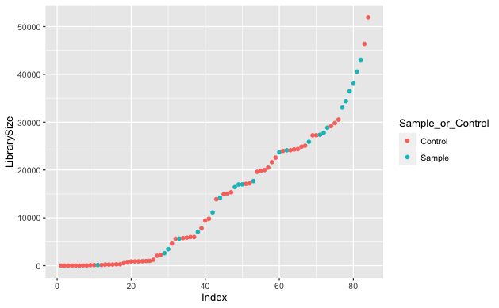

```r
#Step 1: Inspect Library Sizes #######################################################################

#Batch1
df1 <- as.data.frame(sample_data(ps1))
df1$LibrarySize <- sample_sums(ps1)
df1 <- df1[order(df1$LibrarySize),]
df1$Index <- seq(nrow(df1))
ggplot(data=df1, aes(x=Index, y=LibrarySize, color=Sample_or_Control)) + geom_point()
```

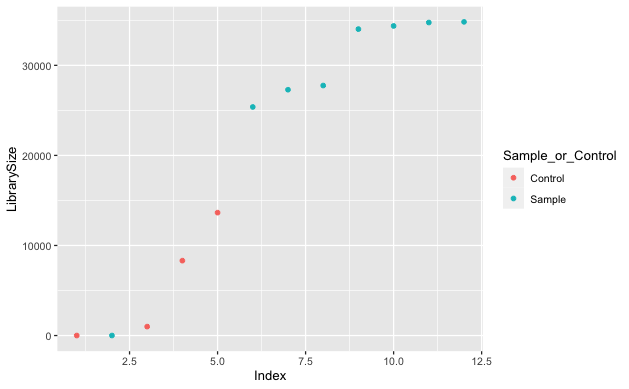

```r
#Batch2
df2 <- as.data.frame(sample_data(ps2))
df2$LibrarySize <- sample_sums(ps2)
df2 <- df2[order(df2$LibrarySize),]
df2$Index <- seq(nrow(df2))
ggplot(data=df2, aes(x=Index, y=LibrarySize, color=Sample_or_Control)) + geom_point()
```

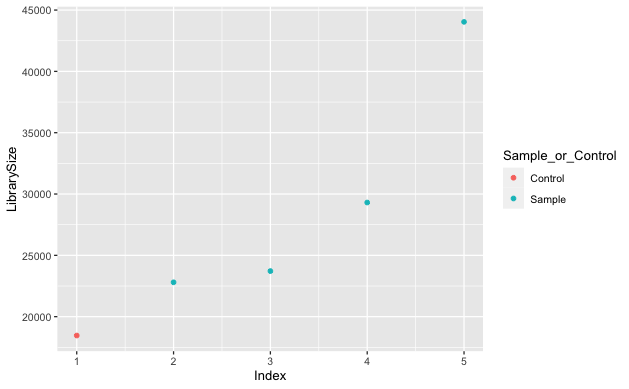

```r
#Batch3
df3 <- as.data.frame(sample_data(ps3))
df3$LibrarySize <- sample_sums(ps3)
df3 <- df3[order(df3$LibrarySize),]
df3$Index <- seq(nrow(df3))
ggplot(data=df3, aes(x=Index, y=LibrarySize, color=Sample_or_Control)) + geom_point()
```

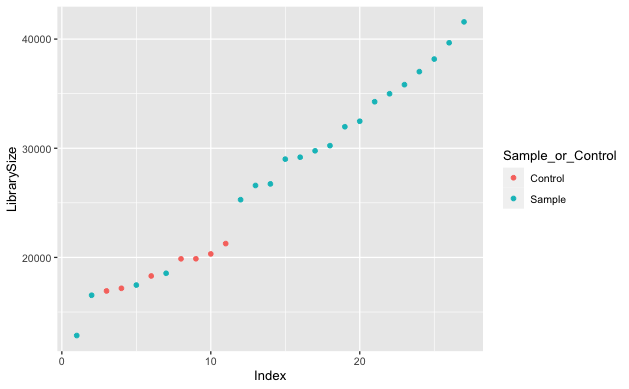

```r
#Batch5
df5 <- as.data.frame(sample_data(ps5))
df5$LibrarySize <- sample_sums(ps5)
df5 <- df5[order(df5$LibrarySize),]
df5$Index <- seq(nrow(df5))
ggplot(data=df5, aes(x=Index, y=LibrarySize, color=Sample_or_Control)) + geom_point()
```

```r
NA
NA
```

```r
#Step 2: Prevalence Method  #######################################################################
#Use a threshold of 0.5 to remove any taxa that are more prevalent in controls than in samples

#Batch1 ##########################################################
sample_data(ps1)$is.neg <- sample_data(ps1)$Sample_or_Control == "Control"
contamdf.prev1 <- isContaminant(ps1, method="prevalence", neg="is.neg")
table(contamdf.prev1$contaminant)
```

```
FALSE  TRUE
 2505    44
```

```r
head(which(contamdf.prev1$contaminant))
```

```
[1] 13 40 41 44 56 61
```

```r
#check with a 0.5 cutoff
contamdf.prev1.05 <- isContaminant(ps1, method="prevalence", neg="is.neg", threshold=0.5)
table(contamdf.prev1.05$contaminant)
```

```
FALSE  TRUE
 2334   215
```

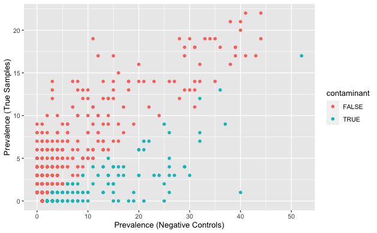

```r
# Make phyloseq object of presence-absence in negative controls and true samples
ps1.pa <- transform_sample_counts(ps1, function(abund) 1*(abund>0))
ps1.pa.neg <- prune_samples(sample_data(ps1.pa)$Sample_or_Control == "Control", ps1.pa)
ps1.pa.pos <- prune_samples(sample_data(ps1.pa)$Sample_or_Control == "Sample", ps1.pa)

# Make data.frame of prevalence in positive and negative samples
df1.pa <- data.frame(pa.pos=taxa_sums(ps1.pa.pos), pa.neg=taxa_sums(ps1.pa.neg),
                      contaminant=contamdf.prev1.05$contaminant)
ggplot(data=df1.pa, aes(x=pa.neg, y=pa.pos, color=contaminant)) + geom_point() +
  xlab("Prevalence (Negative Controls)") + ylab("Prevalence (True Samples)")
```

```r
# Prune Taxa & Remove controls from phyloseq object
ps1.nocontamc <- prune_taxa(!contamdf.prev1.05$contaminant, ps1)
ps1.nocontam <- subset_samples(ps1.nocontamc, ParticipantID != "NONE")


#Batch2 ##########################################################
sample_data(ps2)$is.neg <- sample_data(ps2)$Sample_or_Control == "Control"
contamdf.prev2 <- isContaminant(ps2, method="prevalence", neg="is.neg")
table(contamdf.prev2$contaminant)
```

```
FALSE  TRUE
  596     2
```

```r
head(which(contamdf.prev2$contaminant))
```

```
[1] 51 97
```

```r
#check with a 0.5 cutoff
contamdf.prev2.05 <- isContaminant(ps2, method="prevalence", neg="is.neg", threshold=0.5)
table(contamdf.prev2.05$contaminant)
```

```
FALSE  TRUE
  540    58
```

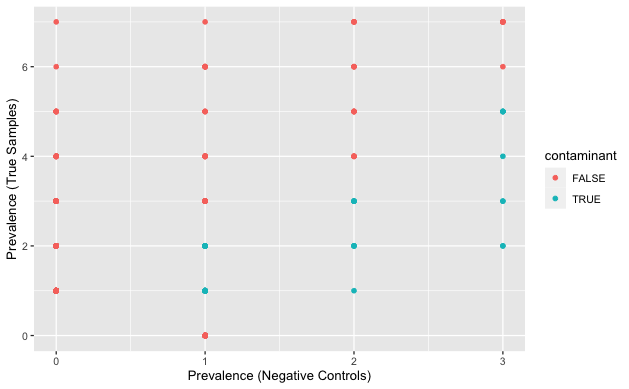

```r
# Make phyloseq object of presence-absence in negative controls and true samples
ps2.pa <- transform_sample_counts(ps2, function(abund) 1*(abund>0))
ps2.pa.neg <- prune_samples(sample_data(ps2.pa)$Sample_or_Control == "Control", ps2.pa)
ps2.pa.pos <- prune_samples(sample_data(ps2.pa)$Sample_or_Control == "Sample", ps2.pa)

# Make data.frame of prevalence in positive and negative samples
df2.pa <- data.frame(pa.pos=taxa_sums(ps2.pa.pos), pa.neg=taxa_sums(ps2.pa.neg),
                      contaminant=contamdf.prev2.05$contaminant)
ggplot(data=df2.pa, aes(x=pa.neg, y=pa.pos, color=contaminant)) + geom_point() +
  xlab("Prevalence (Negative Controls)") + ylab("Prevalence (True Samples)")
```

```r
# Prune Taxa & Remove controls from phyloseq object
ps2.nocontamc <- prune_taxa(!contamdf.prev2.05$contaminant, ps2)
ps2.nocontam <- subset_samples(ps2.nocontamc, ParticipantID != "NONE")


#Batch3 ##########################################################
sample_data(ps3)$is.neg <- sample_data(ps3)$Sample_or_Control == "Control"
contamdf.prev3 <- isContaminant(ps3, method="prevalence", neg="is.neg")
table(contamdf.prev3$contaminant)
```

```
FALSE
  437
```

```r
head(which(contamdf.prev3$contaminant))
```

```
integer(0)
```

```r
#check with a 0.5 cutoff
contamdf.prev3.05 <- isContaminant(ps3, method="prevalence", neg="is.neg", threshold=0.5)
table(contamdf.prev3.05$contaminant)
```

```
FALSE  TRUE
  344    93
```

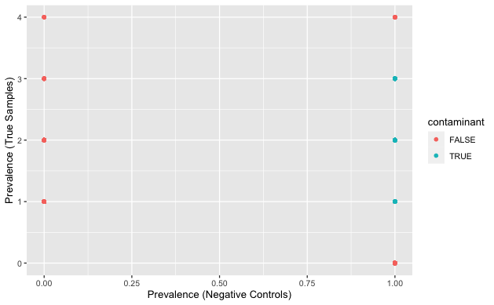

```r
# Make phyloseq object of presence-absence in negative controls and true samples
ps3.pa <- transform_sample_counts(ps3, function(abund) 1*(abund>0))
ps3.pa.neg <- prune_samples(sample_data(ps3.pa)$Sample_or_Control == "Control", ps3.pa)
ps3.pa.pos <- prune_samples(sample_data(ps3.pa)$Sample_or_Control == "Sample", ps3.pa)

# Make data.frame of prevalence in positive and negative samples
df3.pa <- data.frame(pa.pos=taxa_sums(ps3.pa.pos), pa.neg=taxa_sums(ps3.pa.neg),
                      contaminant=contamdf.prev3.05$contaminant)
ggplot(data=df3.pa, aes(x=pa.neg, y=pa.pos, color=contaminant)) + geom_point() +
  xlab("Prevalence (Negative Controls)") + ylab("Prevalence (True Samples)")
```

```r
# Prune Taxa & Remove controls from phyloseq object
ps3.nocontamc <- prune_taxa(!contamdf.prev3.05$contaminant, ps3)
ps3.nocontam <- subset_samples(ps3.nocontamc, ParticipantID != "NONE")


#Batch5 ##########################################################
sample_data(ps5)$is.neg <- sample_data(ps5)$Sample_or_Control == "Control"
contamdf.prev5 <- isContaminant(ps5, method="prevalence", neg="is.neg")
table(contamdf.prev5$contaminant)
```

```
FALSE  TRUE
 1503    81
```

```r
head(which(contamdf.prev5$contaminant))
```

```
[1]  2  5 10 12 17 29
```

```r
#check with a 0.5 cutoff
contamdf.prev5.05 <- isContaminant(ps5, method="prevalence", neg="is.neg", threshold=0.5)
table(contamdf.prev5.05$contaminant)
```

```
FALSE  TRUE
 1420   164
```

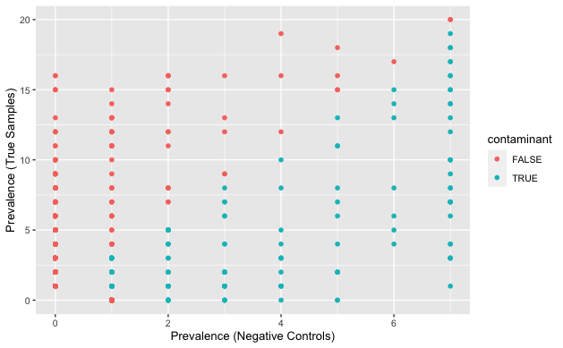

```r
# Make phyloseq object of presence-absence in negative controls and true samples
ps5.pa <- transform_sample_counts(ps5, function(abund) 1*(abund>0))
ps5.pa.neg <- prune_samples(sample_data(ps5.pa)$Sample_or_Control == "Control", ps5.pa)
ps5.pa.pos <- prune_samples(sample_data(ps5.pa)$Sample_or_Control == "Sample", ps5.pa)

# Make data.frame of prevalence in positive and negative samples
df5.pa <- data.frame(pa.pos=taxa_sums(ps5.pa.pos), pa.neg=taxa_sums(ps5.pa.neg),
                      contaminant=contamdf.prev5.05$contaminant)
ggplot(data=df5.pa, aes(x=pa.neg, y=pa.pos, color=contaminant)) + geom_point() +
  xlab("Prevalence (Negative Controls)") + ylab("Prevalence (True Samples)")
```

```r
# Prune Taxa & Remove controls from phyloseq object
ps5.nocontamc <- prune_taxa(!contamdf.prev5.05$contaminant, ps5)
ps5.nocontam <- subset_samples(ps5.nocontamc, ParticipantID != "NONE")
```

## Batch Correction with CombatSeq

```r
#Step 1: Make variables for CombatSeq function
#######################################################################

## Merge phyloseq
ps <- merge_phyloseq(ps1.nocontam, ps2.nocontam, ps3.nocontam, ps5.nocontam)

## Check object for any low count samples and remove ######################
combat1 <- as.data.frame(otu_table(ps))

combat2 <- t(combat1) ## Transpose first

libsize <- colSums(combat2)
#create new phyloseq object with removed samples ######################
#Remove sample with less than 10 counts
combatPS <- subset_samples(ps, ! sample_names(ps) %in% c("S522"))

combatps2 <- as.data.frame(otu_table(combatPS))

#Transpose
combat.ps2 <- t(combatps2)

#Create the batch Vector
batch <- sample_data(combatPS)$Batch

#Step 2: Batch Correction
#######################################################################
# generate count table thats been corrected for batch effect
ps.adj <- ComBat_seq(counts=combat.ps2, batch=batch, group=NULL, full_mod = TRUE)
```

```
Found 4 batches
Using null model in ComBat-seq.
Adjusting for 0 covariate(s) or covariate level(s)
Estimating dispersions
Fitting the GLM model
Shrinkage off - using GLM estimates for parameters
Adjusting the data
```

### Creating the final Phyloseq Object

Here we use the final counts which have been corrected by control and by batch to create a final phyloseq object for downstream analysis. This requires an OTU counts table, sample datatable, and the taxanomic information tables. The phyloseq tree is added in after

```r
#Step 3: Prep to convert back into a phyloseq object
#######################################################################

#1. OTU counts table - CombatSeq output
ps.adj2 <- t(ps.adj)

#2. Sample data - pull from last edited phyloseq object and add in diet data results
MapfileM <- data.frame(sample_data(combatPS))
MapfileM2 <- dplyr::rename(MapfileM, redcapid = ParticipantID)
MapfileM3 <- subset(MapfileM2, select = -c(X, X.1, X.2, X.3, X.4 , X.5, X.6, X.7,
                                          X.8, X.9, X.10, X.11, X.12, X.13, X.14,
                                          X.15, X.16, X.17, X.18, X.19))

DietData <- read_csv(here("Output", "Diet_Output", "Demo_Diet_results.csv"))
MapfileDiet <- merge(MapfileM3, DietData, by = "redcapid")
SampleData <- sample_data(MapfileDiet)
rownames(SampleData) <- SampleData$SampleID

#3. Taxa tables - assign taxa to the adjusted table
taxaM <- assignTaxonomy(ps.adj2, here("Data", "Microbiome_Data", "silva_nr_v132_train_set.fa.gz"),
                        multithread=TRUE)
taxaM <- addSpecies(taxaM, here("Data", "Microbiome_Data", "silva_species_assignment_v132.fa.gz"))


#Step 4: Combine into the final phyloseq object
#######################################################################
ps.f <- phyloseq(otu_table(ps.adj2, taxa_are_rows=FALSE),
               sample_data(SampleData),
               tax_table(taxaM))
```

```r
#Step 1: Remove OTUs with less than 10 counts in all samples
#######################################################################
ps.fc <- filter_taxa(ps.f, function(x) sum(x) > 10, TRUE)
dim(otu_table(ps.fc))
```

```
[1]   54 1224
```

```r
#Step 2: Find taxa that appear in more than 1% of relative abundance
#######################################################################
ps.fr <- transform_sample_counts(ps.fc, function(x) x/sum(x))
ps.fr.p <- filter_taxa(ps.fr, function(x) sum(x) > .01, TRUE)
dim(otu_table(ps.fr.p))
```

```
[1]  54 410
```

```r
otu_to_keep <- colnames(otu_table(ps.fr.p))

#Step 3: Make a normal count filter otutable to only include taxa from the 1% thats NOT transformed to relative abundance
#######################################################################
otu_to_filter <- data.frame(t(otu_table(ps.fc)))
otu_to_filter2 <- rownames_to_column(otu_to_filter, "OTU")
otu_filtered <- data.frame(subset(otu_to_filter2, OTU %in% otu_to_keep))
rownames(otu_filtered)<-NULL
otu_filtered2 <- column_to_rownames(otu_filtered, "OTU")
taxa_to_keep <- rownames(otu_filtered2)
otu_filtered3 <- t(otu_filtered2)

#Step 4: make filtered taxa object
#######################################################################
taxa_to_filter <- data.frame(tax_table(ps.fc))
taxa_to_filter <- rownames_to_column(taxa_to_filter, "OTU")
taxa_filtered <- subset(taxa_to_filter, OTU %in% taxa_to_keep)
rownames(taxa_filtered)<-NULL
taxa_filtered2 <- column_to_rownames(taxa_filtered, "OTU")
taxa_filtered3 <- as.matrix(taxa_filtered2)

#Step 5: Assign filtered counts to phyloseq
#######################################################################
ps.f <- phyloseq(otu_table(otu_filtered3, taxa_are_rows = FALSE),
               sample_data(SampleData),
               tax_table(taxa_filtered3))


write.csv(data.frame(SampleData), here("Output", "Microbiome_Output", "Sample_Data_duplicates.csv"))
```

Add in the phyloseq tree and remove duplicate samples

```r
#Step 6: add in phylo tree using the "ape" package
#######################################################################
phy_tree <- rtree(ntaxa(ps.f), rooted=TRUE, tip.label=taxa_names(ps.f))
ps.f <- merge_phyloseq(ps.f, phy_tree)


#Step 7: Remove duplicate samples
#######################################################################
ps.f <- subset_samples(ps.f, SampleID != "S169" & SampleID !="S406" &
                         SampleID !="S279" & SampleID !="S533" & SampleID !="S554" &
                         SampleID !="S669" & SampleID !="S672")
dim(otu_table(ps.f))
```

```
[1]  47 410
```

```r
write.csv(data.frame(SampleData), here("Output", "Microbiome_Output", "Sample_Data.csv"))
```

Save final Phyloseq object to read in to the analysis scripts

```r
#SaveRDS so we can call back in the object without repeat the analysis for
#######################################################################
saveRDS(ps.f, here("Output", "Microbiome_Output", "Phyloseq_Objects", "ps.rds"))
```